# PS 06

## Name: Xinyu Chang

```python
# import the packages
import pandas as pd
import numpy as np
import matplotlib.pyplot as plt
import statsmodels.formula.api as smf
from sklearn.metrics import mean_squared_error
```

## 1 Who will win the elections?

### 1.1 Load and check

```python
election_df = pd.read_csv("us-elections_2000-2020.csv", sep='\t')
```

```python
election_df.shape
```

```
(37390, 24)
```

```python
election_df.head()
```

|  | FIPS | year | state | state2 | county | office | candidate | party | candidatevotes | totalvotes | ... | EDU600209D | POP010210D | POP220210D | POP250210D | POP320210D | POP400210D | PST110209D | BIRTHS2020 | DEATHS2020 | region |
| --- | --- | --- | --- | --- | --- | --- | --- | --- | --- | --- | --- | --- | --- | --- | --- | --- | --- | --- | --- | --- | --- |
| 0 | 1001 | 2000 | Alabama | AL | Autauga | President | Al Gore | democrat | 4942.0 | 17208 | ... | 31469 | 54571 | 42855 | 9643 | 474 | 1310 | 7085 | 143.0 | 168.0 | south |
| 1 | 1001 | 2000 | Alabama | AL | Autauga | President | George W. Bush | republican | 11993.0 | 17208 | ... | 31469 | 54571 | 42855 | 9643 | 474 | 1310 | 7085 | 143.0 | 168.0 | south |
| 2 | 1001 | 2004 | Alabama | AL | Autauga | President | John Kerry | democrat | 4758.0 | 20081 | ... | 31469 | 54571 | 42855 | 9643 | 474 | 1310 | 7085 | 143.0 | 168.0 | south |
| 3 | 1001 | 2004 | Alabama | AL | Autauga | President | George W. Bush | republican | 15196.0 | 20081 | ... | 31469 | 54571 | 42855 | 9643 | 474 | 1310 | 7085 | 143.0 | 168.0 | south |
| 4 | 1001 | 2008 | Alabama | AL | Autauga | President | Barack Obama | democrat | 6093.0 | 23641 | ... | 31469 | 54571 | 42855 | 9643 | 474 | 1310 | 7085 | 143.0 | 168.0 | south |

5 rows × 24 columns

```python
election_df.isna().sum()
```

```
FIPS                 0
year                 0
state                0
state2               0
county               0
office               0
candidate            0
party                0
candidatevotes       4
totalvotes           0
income            6762
population        6762
LND010200D           0
EDU695209D           0
EDU600209D           0
POP010210D           0
POP220210D           0
POP250210D           0
POP320210D           0
POP400210D           0
PST110209D           0
BIRTHS2020          20
DEATHS2020          20
region               0
dtype: int64
```

There are 37390 rows and 24 columns in the dataset. The first 5 lines of data look reasonable and the data fits the type that the column defines. Also, there are 6762 missing values for the income column and the population column. There are 20 missing values for the BIRTHS2020 and DEATHS2020 column.

### 1.2 Fill missings

#### 1.Print the rows of the data frame from index 6264 to 6271 (i.e. these index values of the dataframe). For simplicity, you may only include variables fips, county, year and income.

```python
election_df.columns.get_loc('FIPS')
```

```
0
```

```python
election_df.columns.get_loc('county')
```

```
4
```

```python
election_df.columns.get_loc('year')
```

```
1
```

```python
election_df.columns.get_loc('income')
```

```
10
```

```python
print(election_df.iloc[6264: 6271, [0, 1, 4, 10]])
```

```
       FIPS  year        county   income
6264  15007  2016         Kauai  44958.0
6265  15007  2016         Kauai  44958.0
6266  15007  2020  Kauai County      NaN
6267  15007  2020  Kauai County      NaN
6268  15009  2000          Maui      NaN
6269  15009  2000          Maui      NaN
6270  15009  2004          Maui      NaN
```

#### 2. You see that some income values are missing in the example from question 1.

#### (a) Which values do you expect to see instead of NA-s in lines 6266, 6267, 6268 and 6269?

We can expect the following values instead of NAs in lines 6266, 6267, 6268, and 6269:

For lines 6266 and 6267 (Kauai County), the most recent available 'income' value is 44,958 from the year 2016 (index 6264 and 6265) due to their affiliation with the same county. For lines 6268 and 6269 (Maui County), we don't have enough data in the provided output to determine the most recent 'income' value.But the income value will be same for the line 6268 and line 6269 due to their affiliation with the same county.

#### (b)How is it related to the non-missing income, county and fips values?

The missing 'income' values are related to the non-missing 'income', 'county', and 'FIPS' values because they help us determine the most recent 'income' data available for the corresponding county. Even though their county names may be different, we can still use the same FIP code to match between counties and fill in the missing income value because the same FIPS correspond the same "income" value.

#### 3. Fill the missings in all columns you need (not only in income) with the most recent values that exist in the data. Ensure you do not fill missings with values from other counties.

```python
sorted_election = election_df.sort_values(by=['FIPS', 'year'])
sorted_election
```

|  | FIPS | year | state | state2 | county | office | candidate | party | candidatevotes | totalvotes | ... | EDU600209D | POP010210D | POP220210D | POP250210D | POP320210D | POP400210D | PST110209D | BIRTHS2020 | DEATHS2020 | region |
| --- | --- | --- | --- | --- | --- | --- | --- | --- | --- | --- | --- | --- | --- | --- | --- | --- | --- | --- | --- | --- | --- |
| 0 | 1001 | 2000 | Alabama | AL | Autauga | President | Al Gore | democrat | 4942.0 | 17208 | ... | 31469 | 54571 | 42855 | 9643 | 474 | 1310 | 7085 | 143.0 | 168.0 | south |
| 1 | 1001 | 2000 | Alabama | AL | Autauga | President | George W. Bush | republican | 11993.0 | 17208 | ... | 31469 | 54571 | 42855 | 9643 | 474 | 1310 | 7085 | 143.0 | 168.0 | south |
| 2 | 1001 | 2004 | Alabama | AL | Autauga | President | John Kerry | democrat | 4758.0 | 20081 | ... | 31469 | 54571 | 42855 | 9643 | 474 | 1310 | 7085 | 143.0 | 168.0 | south |
| 3 | 1001 | 2004 | Alabama | AL | Autauga | President | George W. Bush | republican | 15196.0 | 20081 | ... | 31469 | 54571 | 42855 | 9643 | 474 | 1310 | 7085 | 143.0 | 168.0 | south |
| 4 | 1001 | 2008 | Alabama | AL | Autauga | President | Barack Obama | democrat | 6093.0 | 23641 | ... | 31469 | 54571 | 42855 | 9643 | 474 | 1310 | 7085 | 143.0 | 168.0 | south |
| ... | ... | ... | ... | ... | ... | ... | ... | ... | ... | ... | ... | ... | ... | ... | ... | ... | ... | ... | ... | ... | ... |
| 37385 | 56045 | 2012 | Wyoming | WY | Weston | President | Mitt Romney | republican | 2821.0 | 3359 | ... | 4681 | 7208 | 6885 | 21 | 20 | 216 | 365 | 16.0 | 14.0 | west |
| 37386 | 56045 | 2016 | Wyoming | WY | Weston | President | Hillary Clinton | democrat | 299.0 | 3526 | ... | 4681 | 7208 | 6885 | 21 | 20 | 216 | 365 | 16.0 | 14.0 | west |
| 37387 | 56045 | 2016 | Wyoming | WY | Weston | President | Donald Trump | republican | 3033.0 | 3526 | ... | 4681 | 7208 | 6885 | 21 | 20 | 216 | 365 | 16.0 | 14.0 | west |
| 37388 | 56045 | 2020 | Wyoming | WY | Weston County | President | Donald Trump | republican | 3107.0 | 3542 | ... | 4681 | 7208 | 6885 | 21 | 20 | 216 | 365 | 16.0 | 14.0 | west |
| 37389 | 56045 | 2020 | Wyoming | WY | Weston County | President | Joshep Biden | democrat | 360.0 | 3542 | ... | 4681 | 7208 | 6885 | 21 | 20 | 216 | 365 | 16.0 | 14.0 | west |

37390 rows × 24 columns

```python
sorted_election['FIPS2'] = sorted_election['FIPS']
necessary_columns = ['income', 'population', 'LND010200D', 'EDU695209D', 'EDU600209D', 'BIRTHS2020', 'DEATHS2020']
for column in necessary_columns:
    sorted_election[column] = sorted_election.groupby('FIPS2')[column].fillna(method='ffill')
print(sorted_election.head())
```

```
   FIPS  year    state state2   county     office       candidate       party  \
0  1001  2000  Alabama     AL  Autauga  President         Al Gore    democrat
1  1001  2000  Alabama     AL  Autauga  President  George W. Bush  republican
2  1001  2004  Alabama     AL  Autauga  President      John Kerry    democrat
3  1001  2004  Alabama     AL  Autauga  President  George W. Bush  republican
4  1001  2008  Alabama     AL  Autauga  President    Barack Obama    democrat

   candidatevotes  totalvotes  ...  POP010210D  POP220210D  POP250210D  \
0          4942.0       17208  ...       54571       42855        9643
1         11993.0       17208  ...       54571       42855        9643
2          4758.0       20081  ...       54571       42855        9643
3         15196.0       20081  ...       54571       42855        9643
4          6093.0       23641  ...       54571       42855        9643

   POP320210D  POP400210D  PST110209D  BIRTHS2020  DEATHS2020  region  FIPS2
0         474        1310        7085       143.0       168.0   south   1001
1         474        1310        7085       143.0       168.0   south   1001
2         474        1310        7085       143.0       168.0   south   1001
3         474        1310        7085       143.0       168.0   south   1001
4         474        1310        7085       143.0       168.0   south   1001

[5 rows x 25 columns]
```

#### 4. Print out the same lines you did above in 1.1. Does it look what you expected? Pay close attention to the relationship between the FIPS code and the counties.

```python
print(sorted_election.iloc[6264: 6271, [0, 1, 4, 10]])
```

```
       FIPS  year        county   income
6264  15007  2016         Kauai  44958.0
6265  15007  2016         Kauai  44958.0
6266  15007  2020  Kauai County  44958.0
6267  15007  2020  Kauai County  44958.0
6268  15009  2000          Maui      NaN
6269  15009  2000          Maui      NaN
6270  15009  2004          Maui      NaN
```

In this output, we can see that the missing income values for Kauai County(with the FIPS 15007) have been filled with the most recent available value (44958.0), which is my expected result, but there are still missing values for Maui, as there were no earlier data points to fill those missing values.

### 1.3 Feature engineering

#### 1.Make a new data frame that only contains 2020 data, and that contains a binary variable: whether or not democrats won in that county in 2020.

```python
election_2020 = sorted_election[sorted_election['year'] == 2020]
election_2020
```

|  | FIPS | year | state | state2 | county | office | candidate | party | candidatevotes | totalvotes | ... | POP010210D | POP220210D | POP250210D | POP320210D | POP400210D | PST110209D | BIRTHS2020 | DEATHS2020 | region | FIPS2 |
| --- | --- | --- | --- | --- | --- | --- | --- | --- | --- | --- | --- | --- | --- | --- | --- | --- | --- | --- | --- | --- | --- |
| 10 | 1001 | 2020 | Alabama | AL | Autauga County | President | Donald Trump | republican | 19838.0 | 27770 | ... | 54571 | 42855 | 9643 | 474 | 1310 | 7085 | 143.0 | 168.0 | south | 1001 |
| 11 | 1001 | 2020 | Alabama | AL | Autauga County | President | Joshep Biden | democrat | 7503.0 | 27770 | ... | 54571 | 42855 | 9643 | 474 | 1310 | 7085 | 143.0 | 168.0 | south | 1001 |
| 22 | 1003 | 2020 | Alabama | AL | Baldwin County | President | Donald Trump | republican | 83544.0 | 109679 | ... | 182265 | 156153 | 17105 | 1348 | 7992 | 39463 | 527.0 | 661.0 | south | 1003 |
| 23 | 1003 | 2020 | Alabama | AL | Baldwin County | President | Joshep Biden | democrat | 24578.0 | 109679 | ... | 182265 | 156153 | 17105 | 1348 | 7992 | 39463 | 527.0 | 661.0 | south | 1003 |
| 34 | 1005 | 2020 | Alabama | AL | Barbour County | President | Donald Trump | republican | 5622.0 | 10518 | ... | 27457 | 13180 | 12875 | 107 | 1387 | 699 | 64.0 | 109.0 | south | 1005 |
| ... | ... | ... | ... | ... | ... | ... | ... | ... | ... | ... | ... | ... | ... | ... | ... | ... | ... | ... | ... | ... | ... |
| 37365 | 56041 | 2020 | Wyoming | WY | Uinta County | President | Joshep Biden | democrat | 1591.0 | 9402 | ... | 21118 | 19514 | 55 | 61 | 1855 | 1185 | 50.0 | 49.0 | west | 56041 |
| 37376 | 56043 | 2020 | Wyoming | WY | Washakie County | President | Donald Trump | republican | 3245.0 | 4012 | ... | 8533 | 7795 | 22 | 48 | 1162 | -380 | 18.0 | 32.0 | west | 56043 |
| 37377 | 56043 | 2020 | Wyoming | WY | Washakie County | President | Joshep Biden | democrat | 651.0 | 4012 | ... | 8533 | 7795 | 22 | 48 | 1162 | -380 | 18.0 | 32.0 | west | 56043 |
| 37388 | 56045 | 2020 | Wyoming | WY | Weston County | President | Donald Trump | republican | 3107.0 | 3542 | ... | 7208 | 6885 | 21 | 20 | 216 | 365 | 16.0 | 14.0 | west | 56045 |
| 37389 | 56045 | 2020 | Wyoming | WY | Weston County | President | Joshep Biden | democrat | 360.0 | 3542 | ... | 7208 | 6885 | 21 | 20 | 216 | 365 | 16.0 | 14.0 | west | 56045 |

6222 rows × 25 columns

```python
democrats_votes = election_2020[election_2020['party'] == 'democrat'].candidatevotes.values
democrats_votes
```

```
array([ 7503., 24578.,  4816., ...,  1591.,   651.,   360.])
```

```python
republicans_votes = election_2020[election_2020['party'] == 'republican'].candidatevotes.values
republicans_votes
```

```
array([19838., 83544.,  5622., ...,  7496.,  3245.,  3107.])
```

```python
democrats_won = democrats_votes > republicans_votes
```

```python
election_2020 = election_2020[election_2020.party == 'democrat']
election_2020['democrats_won'] = np.where(democrats_won == True, 1, 0)
election_2020.head()
```

|  | FIPS | year | state | state2 | county | office | candidate | party | candidatevotes | totalvotes | ... | POP220210D | POP250210D | POP320210D | POP400210D | PST110209D | BIRTHS2020 | DEATHS2020 | region | FIPS2 | democrats_won |
| --- | --- | --- | --- | --- | --- | --- | --- | --- | --- | --- | --- | --- | --- | --- | --- | --- | --- | --- | --- | --- | --- |
| 11 | 1001 | 2020 | Alabama | AL | Autauga County | President | Joshep Biden | democrat | 7503.0 | 27770 | ... | 42855 | 9643 | 474 | 1310 | 7085 | 143.0 | 168.0 | south | 1001 | 0 |
| 23 | 1003 | 2020 | Alabama | AL | Baldwin County | President | Joshep Biden | democrat | 24578.0 | 109679 | ... | 156153 | 17105 | 1348 | 7992 | 39463 | 527.0 | 661.0 | south | 1003 | 0 |
| 35 | 1005 | 2020 | Alabama | AL | Barbour County | President | Joshep Biden | democrat | 4816.0 | 10518 | ... | 13180 | 12875 | 107 | 1387 | 699 | 64.0 | 109.0 | south | 1005 | 0 |
| 47 | 1007 | 2020 | Alabama | AL | Bibb County | President | Joshep Biden | democrat | 1986.0 | 9595 | ... | 17381 | 5047 | 22 | 406 | 1698 | 62.0 | 90.0 | south | 1007 | 0 |
| 59 | 1009 | 2020 | Alabama | AL | Blount County | President | Joshep Biden | democrat | 2640.0 | 27588 | ... | 53068 | 761 | 117 | 4626 | 7323 | 152.0 | 220.0 | south | 1009 | 0 |

5 rows × 26 columns

#### 2. Create auxiliary variables: population density (population divided by land area); and percentage of college graduates.

```python
election_2020['population_density'] = election_2020['population'] / election_2020['LND010200D']  / 1000
election_2020['college_grad_percentage'] = (election_2020['EDU695209D'] / election_2020['EDU600209D']) * 100
election_2020.head()
```

|  | FIPS | year | state | state2 | county | office | candidate | party | candidatevotes | totalvotes | ... | POP320210D | POP400210D | PST110209D | BIRTHS2020 | DEATHS2020 | region | FIPS2 | democrats_won | population_density | college_grad_percentage |
| --- | --- | --- | --- | --- | --- | --- | --- | --- | --- | --- | --- | --- | --- | --- | --- | --- | --- | --- | --- | --- | --- |
| 11 | 1001 | 2020 | Alabama | AL | Autauga County | President | Joshep Biden | democrat | 7503.0 | 27770 | ... | 474 | 1310 | 7085 | 143.0 | 168.0 | south | 1001 | 0 | 0.091394 | 7.261114 |
| 23 | 1003 | 2020 | Alabama | AL | Baldwin County | President | Joshep Biden | democrat | 24578.0 | 109679 | ... | 1348 | 7992 | 39463 | 527.0 | 661.0 | south | 1003 | 0 | 0.102421 | 9.153772 |
| 35 | 1005 | 2020 | Alabama | AL | Barbour County | President | Joshep Biden | democrat | 4816.0 | 10518 | ... | 107 | 1387 | 699 | 64.0 | 109.0 | south | 1005 | 0 | 0.028530 | 5.295336 |
| 47 | 1007 | 2020 | Alabama | AL | Bibb County | President | Joshep Biden | democrat | 1986.0 | 9595 | ... | 22 | 406 | 1698 | 62.0 | 90.0 | south | 1007 | 0 | 0.036071 | 3.202429 |
| 59 | 1009 | 2020 | Alabama | AL | Blount County | President | Joshep Biden | democrat | 2640.0 | 27588 | ... | 117 | 4626 | 7323 | 152.0 | 220.0 | south | 1009 | 0 | 0.088371 | 4.057496 |

5 rows × 28 columns

#### 3. Are countries with younger population more or less democratic? Compute (estimate) yearly birth rate and death rate. This is normally done as as the number of births/deaths per 1000 people per year, please do the same!

```python
election_2020['birth_rate'] = election_2020['BIRTHS2020'] / election_2020['population'] * 1000 * 4
election_2020['death_rate'] = election_2020['DEATHS2020'] / election_2020['population'] * 1000 * 4
election_2020.head()
```

|  | FIPS | year | state | state2 | county | office | candidate | party | candidatevotes | totalvotes | ... | PST110209D | BIRTHS2020 | DEATHS2020 | region | FIPS2 | democrats_won | population_density | college_grad_percentage | birth_rate | death_rate |
| --- | --- | --- | --- | --- | --- | --- | --- | --- | --- | --- | --- | --- | --- | --- | --- | --- | --- | --- | --- | --- | --- |
| 11 | 1001 | 2020 | Alabama | AL | Autauga County | President | Joshep Biden | democrat | 7503.0 | 27770 | ... | 7085 | 143.0 | 168.0 | south | 1001 | 0 | 0.091394 | 7.261114 | 10.354253 | 12.164437 |
| 23 | 1003 | 2020 | Alabama | AL | Baldwin County | President | Joshep Biden | democrat | 24578.0 | 109679 | ... | 39463 | 527.0 | 661.0 | south | 1003 | 0 | 0.102421 | 9.153772 | 10.154094 | 12.735969 |
| 35 | 1005 | 2020 | Alabama | AL | Barbour County | President | Joshep Biden | democrat | 4816.0 | 10518 | ... | 699 | 64.0 | 109.0 | south | 1005 | 0 | 0.028530 | 5.295336 | 9.920174 | 16.895296 |
| 47 | 1007 | 2020 | Alabama | AL | Bibb County | President | Joshep Biden | democrat | 1986.0 | 9595 | ... | 1698 | 62.0 | 90.0 | south | 1007 | 0 | 0.036071 | 3.202429 | 10.980253 | 15.939077 |
| 59 | 1009 | 2020 | Alabama | AL | Blount County | President | Joshep Biden | democrat | 2640.0 | 27588 | ... | 7323 | 152.0 | 220.0 | south | 1009 | 0 | 0.088371 | 4.057496 | 10.575017 | 15.305945 |

5 rows × 30 columns

#### 4. Ensure that the variables you are going to use are in a reasonable range!

```python
election_2020 = election_2020[election_2020['college_grad_percentage'] >= 0]
election_2020 = election_2020[election_2020['population_density'] >= 0]
election_2020 = election_2020[election_2020['LND010200D'] > 0]
election_2020 = election_2020.dropna()
election_2020.head()
```

|  | FIPS | year | state | state2 | county | office | candidate | party | candidatevotes | totalvotes | ... | PST110209D | BIRTHS2020 | DEATHS2020 | region | FIPS2 | democrats_won | population_density | college_grad_percentage | birth_rate | death_rate |
| --- | --- | --- | --- | --- | --- | --- | --- | --- | --- | --- | --- | --- | --- | --- | --- | --- | --- | --- | --- | --- | --- |
| 11 | 1001 | 2020 | Alabama | AL | Autauga County | President | Joshep Biden | democrat | 7503.0 | 27770 | ... | 7085 | 143.0 | 168.0 | south | 1001 | 0 | 0.091394 | 7.261114 | 10.354253 | 12.164437 |
| 23 | 1003 | 2020 | Alabama | AL | Baldwin County | President | Joshep Biden | democrat | 24578.0 | 109679 | ... | 39463 | 527.0 | 661.0 | south | 1003 | 0 | 0.102421 | 9.153772 | 10.154094 | 12.735969 |
| 35 | 1005 | 2020 | Alabama | AL | Barbour County | President | Joshep Biden | democrat | 4816.0 | 10518 | ... | 699 | 64.0 | 109.0 | south | 1005 | 0 | 0.028530 | 5.295336 | 9.920174 | 16.895296 |
| 47 | 1007 | 2020 | Alabama | AL | Bibb County | President | Joshep Biden | democrat | 1986.0 | 9595 | ... | 1698 | 62.0 | 90.0 | south | 1007 | 0 | 0.036071 | 3.202429 | 10.980253 | 15.939077 |
| 59 | 1009 | 2020 | Alabama | AL | Blount County | President | Joshep Biden | democrat | 2640.0 | 27588 | ... | 7323 | 152.0 | 220.0 | south | 1009 | 0 | 0.088371 | 4.057496 | 10.575017 | 15.305945 |

5 rows × 30 columns

```python
election_2020['population_density'].min(), election_2020['population_density'].max()
```

```
(0.00017285957006722317, 48.42887177968611)
```

```python
election_2020['college_grad_percentage'].min(), election_2020['college_grad_percentage'].max()
```

```
(0.0, 37.00556242274413)
```

### 1.4 Model

#### 1. Estimate logistic regression model where you explain democrats’ winning with population density, education level, income, birth rate, death rate, and census region.

```python
election_2020['income'] = election_2020['income'] / 1000
```

```python
m = smf.logit('democrats_won ~ population_density + college_grad_percentage + income + region + birth_rate + death_rate', \
              data=election_2020).fit()
m.get_margeff().summary()
```

```
Optimization terminated successfully.
         Current function value: 0.304644
         Iterations 8
```

Logit Marginal Effects

| Dep. Variable: | democrats_won |
| --- | --- |
| Method: | dydx |
| At: | overall |

|  | dy/dx | std err | z | P>\|z\| | [0.025 | 0.975] |
| --- | --- | --- | --- | --- | --- | --- |
| region[T.northeast] | 0.1163 | 0.020 | 5.902 | 0.000 | 0.078 | 0.155 |
| region[T.south] | 0.0558 | 0.015 | 3.788 | 0.000 | 0.027 | 0.085 |
| region[T.west] | 0.1316 | 0.017 | 7.916 | 0.000 | 0.099 | 0.164 |
| population_density | 0.2155 | 0.023 | 9.455 | 0.000 | 0.171 | 0.260 |
| college_grad_percentage | 0.0240 | 0.002 | 12.301 | 0.000 | 0.020 | 0.028 |
| income | -0.0025 | 0.001 | -3.866 | 0.000 | -0.004 | -0.001 |
| birth_rate | -0.0013 | 0.002 | -0.633 | 0.527 | -0.006 | 0.003 |
| death_rate | -0.0033 | 0.002 | -1.914 | 0.056 | -0.007 | 7.8e-05 |

#### 2. Why do we use logistic regression here, instead of linear regression?

We use logistic regression instead of linear regression because the dependent variable, Democrats winning, is a binary variable (0 or 1) representing a categorical outcome. Logistic regression is specifically designed for modeling binary outcomes and is appropriate when the response variable is not continuous and numerical value but rather belongs to a specific category or class. Linear regression, on the other hand, is suitable for modeling continuous and numerical outcomes.

#### 3. Interpret the results. Which results are statistically significant?

The reference category is midwest.

The coefficient for the variable region[T.northeast] is 0.1163. This means that, holding other variables constant, the Northeast region is approximately 11.63% more democratic.

The coefficient for the variable region[T.south] is 0.0558. Holding other variables constant, the South region is approximately 5.58% more democratic.

The coefficient for the variable region[T.west] is 0.1316. Holding other variables constant, the West region is approximately 13.16% more democratic.

For the variable birth_rate, a one-unit increase (which means an increase by one birth per 1,000 people) decreases the probability of Democrats winning by 0.13%, all else being constant. However, this effect is not statistically significant (p-value is 0.527 which is greater than the typical significance level of 0.05), meaning we cannot be confident that the birth rate has a real effect on the probability of Democrats winning.

For the variable death_rate, a one-unit increase (which means an increase by one death per 1,000 people) decreases the probability of Democrats winning by 0.33%, all else being constant. However, this effect is not statistically significant (since its p-value is 0.056, which is greater than the typical significance level of 0.05), meaning we cannot be confident that the death rate has a real effect on the probability of Democrats winning.

Except for the birth rate(0.527) and death rate(0.056), all the coefficients have p-values less than 0.05(all with the value of 0.000) indicating that they are statistically significant at the 5% significance level. This suggests that population density, college grad percentage, income, and region are all significant factors in explaining Democrats winning in the 2020 elections. However, the death rate and birth rate are not significant factors in explaining Democrats winning in the 2020 elections.

## 2 Model AirBnB Price

### 2.1 Load an clean

#### 1. Load data. I recommend to select only the variables you need below, bedrooms, price, and accommodates. You may return here again and change the variable selection as you need. Even better, check out the usecols argument for read_csv. Do the basic checks.

```python
air_df = pd.read_csv("airbnb-bangkok-listings.csv", usecols=["bedrooms", "price", "accommodates","room_type"], sep = ",")
air_df.head()
```

|  | room_type | accommodates | bedrooms | price |
| --- | --- | --- | --- | --- |
| 0 | Entire home/apt | 3 | 1.0 | $1,845.00 |
| 1 | Private room | 2 | 1.0 | $1,275.00 |
| 2 | Private room | 2 | 1.0 | $800.00 |
| 3 | Private room | 2 | 1.0 | $800.00 |
| 4 | Private room | 2 | 1.0 | $1,845.00 |

```python
air_df.shape
```

```
(17040, 4)
```

```python
air_df.isna().sum()
```

```
room_type          0
accommodates       0
bedrooms        1840
price              0
dtype: int64
```

There are 17040 rows and 4 columns in the dataset. The first 5 lines of data look reasonable and the data fits the type that the column defines. However, there are 1840 missing values for the "bedrooms" column.

```python
air_df.bedrooms.value_counts()
```

```
1.0     11923
2.0      2243
3.0       582
4.0       225
5.0        91
6.0        48
10.0       22
7.0        22
8.0        12
9.0         7
20.0        6
11.0        4
12.0        3
30.0        2
15.0        2
16.0        2
40.0        1
23.0        1
39.0        1
50.0        1
25.0        1
46.0        1
Name: bedrooms, dtype: int64
```

#### 2. Do the basic data cleaning:

#### (a) convert price to numeric.

```python
air_df["price"] = air_df["price"].replace('[\$\,\.]', '', regex=True).astype(int)
air_df["price"] = (air_df["price"] / 100).apply(pd.to_numeric).astype(int)
air_df = air_df[air_df["price"] != 0]
air_df.sample(5)
```

|  | room_type | accommodates | bedrooms | price |
| --- | --- | --- | --- | --- |
| 9053 | Private room | 2 | 1.0 | 700 |
| 1656 | Entire home/apt | 2 | 1.0 | 1342 |
| 12642 | Private room | 2 | NaN | 1438 |
| 7316 | Shared room | 2 | 1.0 | 800 |
| 5267 | Shared room | 1 | 1.0 | 400 |

#### (b) remove entries with missing or invalid price, bedrooms, and other variables you need below

```python
air_df.shape
```

```
(17039, 4)
```

```python
air_df.describe()
```

|  | accommodates | bedrooms | price |
| --- | --- | --- | --- |
| count | 17039.000000 | 15200.000000 | 17039.000000 |
| mean | 3.134574 | 1.373421 | 2237.898996 |
| std | 2.201793 | 1.273414 | 7066.783256 |
| min | 1.000000 | 1.000000 | 6.000000 |
| 25% | 2.000000 | 1.000000 | 757.000000 |
| 50% | 2.000000 | 1.000000 | 1199.000000 |
| 75% | 4.000000 | 1.000000 | 2000.000000 |
| max | 16.000000 | 50.000000 | 335482.000000 |

There are some missing values for the bedrooms. Maybe there is studio or the shared room so it doesn't contain the bedrooms.

```python
air_new = air_df[air_df.price > 0].dropna()
air_new.shape
```

```
(15200, 4)
```

#### 3. Analyze the distribution of price. Does it look like normal? Does it look like something else? Does it suggest you should do a log-transformation?

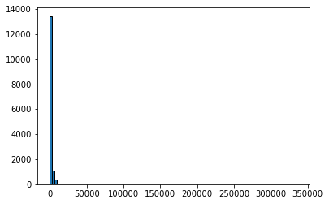

```python
price_his = plt.hist(air_new["price"], bins=100, edgecolor="black")
```

Based on the analysis of the distribution of the price variable, we can observe that it is highly right-skewed, meaning that the majority of prices are concentrated towards the lower end, with a long tail towards higher prices. This distribution does not resemble a normal distribution.The highly right-skewed distribution suggests that a log-transformation could be beneficial. By applying a log-transformation to the price variable, we can compress the range of values and reduce the skewness, making the distribution more symmetric and closer to a normal distribution.

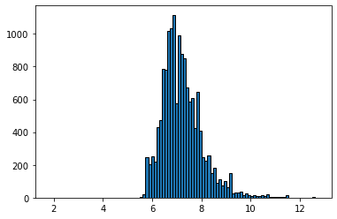

```python
price_log_hist = plt.hist(np.log(air_new['price']), bins=100, edgecolor='black')
```

#### 4. Convert the number of bedrooms into another variable with a limited number of categories only, such as 0, 1, 2, 3, 4+, and use these categories in the models below.

```python
air_new["new_bedroom_type"] = pd.cut(air_new.bedrooms,
                                     bins= [1, 2, 3, 4, np.inf],
                                     labels = ["1", "2", "3", "4+"],
                                     right = False)
air_new.head()
```

|  | room_type | accommodates | bedrooms | price | new_bedroom_type |
| --- | --- | --- | --- | --- | --- |
| 0 | Entire home/apt | 3 | 1.0 | 1845 | 1 |
| 1 | Private room | 2 | 1.0 | 1275 | 1 |
| 2 | Private room | 2 | 1.0 | 800 | 1 |
| 3 | Private room | 2 | 1.0 | 800 | 1 |
| 4 | Private room | 2 | 1.0 | 1845 | 1 |

```python
bedroom_counts = air_new["new_bedroom_type"].value_counts()
print(bedroom_counts)
```

```
1     11923
2      2243
3       582
4+      452
Name: new_bedroom_type, dtype: int64
```

### 2.2 Model

#### 1. Run a linear regression where you explain the listing price with number of bedrooms where bedrooms uses these categories. Interpret the results, including R2.

```python
m_air = smf.ols('price ~ new_bedroom_type', data=air_new).fit()
m_air.summary()
```

OLS Regression Results

| Dep. Variable: | price | R-squared: | 0.036 |
| --- | --- | --- | --- |
| Model: | OLS | Adj. R-squared: | 0.035 |
| Method: | Least Squares | F-statistic: | 186.5 |
| Date: | Fri, 19 May 2023 | Prob (F-statistic): | 9.32e-119 |
| Time: | 06:10:39 | Log-Likelihood: | -1.5589e+05 |
| No. Observations: | 15200 | AIC: | 3.118e+05 |
| Df Residuals: | 15196 | BIC: | 3.118e+05 |
| Df Model: | 3 |  |  |
| Covariance Type: | nonrobust |  |  |

|  | coef | std err | t | P>\|t\| | [0.025 | 0.975] |
| --- | --- | --- | --- | --- | --- | --- |
| Intercept | 1742.2689 | 63.041 | 27.637 | 0.000 | 1618.701 | 1865.836 |
| new_bedroom_type[T.2] | 1481.0031 | 158.427 | 9.348 | 0.000 | 1170.466 | 1791.540 |
| new_bedroom_type[T.3] | 3317.3668 | 292.214 | 11.353 | 0.000 | 2744.591 | 3890.142 |
| new_bedroom_type[T.4+] | 6592.1869 | 329.856 | 19.985 | 0.000 | 5945.629 | 7238.745 |

| Omnibus: | 36718.532 | Durbin-Watson: | 1.874 |
| --- | --- | --- | --- |
| Prob(Omnibus): | 0.000 | Jarque-Bera (JB): | 557010065.623 |
| Skew: | 25.064 | Prob(JB): | 0.00 |
| Kurtosis: | 939.470 | Cond. No. | 6.02 |

Notes:  
[1] Standard Errors assume that the covariance matrix of the errors is correctly specified.

The intercept term of 1742.2689 represents the expected listing price when the number of bedrooms is 1 (the reference category).

The R-squared value is 0.036, which means that approximately 3.6% of the variation in the listing price can be explained by the number of bedrooms. This indicates that the number of bedrooms alone is not a powerful predictor of the listing price.

All the coefficients in this regression model are statistically significant at the 0.05 level. This conclusion is based on the p-values associated with the t-statistics for each coefficient (Intercept, C(new_bedroom_type)[T.2], C(new_bedroom_type)[T.3], and C(new_bedroom_type)[T.4+]), all of which are less than 0.00(less than 0.05). Therefore, we can reject the null hypothesis that these coefficients are zero, and conclude that the number of bedrooms is a significant predictor of the price in the model.

The coefficient for "C(new_bedroom_type)[T.2]" is 1481.0031, which means that, on average, the listing price is expected to be approximately 1,481 more units when the number of bedrooms is 2 compared to 1 bedroom.

The coefficient for "C(new_bedroom_type)[T.3]" is 3317.3668, indicating that the expected listing price is approximately 3,317 more units for 3 bedrooms compared to 1 bedroom.

The coefficient for "C(new_bedroom_type)[T.4+]" is 6592.1869, suggesting that the expected listing price is approximately 6,592 more units for 4 or more bedrooms compared to 1 bedroom.

#### 2. Now repeat the process with the model where you analyze log price instead of price. Interpret the results. Which model behaves better in the sense of R2?

```python
air_new['price_log'] = np.log(air_new["price"])
```

```python
m_log = smf.ols('price_log ~ new_bedroom_type', data=air_new).fit()
m_log.summary()
```

OLS Regression Results

| Dep. Variable: | price_log | R-squared: | 0.203 |
| --- | --- | --- | --- |
| Model: | OLS | Adj. R-squared: | 0.203 |
| Method: | Least Squares | F-statistic: | 1293. |
| Date: | Fri, 19 May 2023 | Prob (F-statistic): | 0.00 |
| Time: | 06:11:32 | Log-Likelihood: | -16912. |
| No. Observations: | 15200 | AIC: | 3.383e+04 |
| Df Residuals: | 15196 | BIC: | 3.386e+04 |
| Df Model: | 3 |  |  |
| Covariance Type: | nonrobust |  |  |

|  | coef | std err | t | P>\|t\| | [0.025 | 0.975] |
| --- | --- | --- | --- | --- | --- | --- |
| Intercept | 7.0150 | 0.007 | 1040.367 | 0.000 | 7.002 | 7.028 |
| new_bedroom_type[T.2] | 0.6781 | 0.017 | 40.014 | 0.000 | 0.645 | 0.711 |
| new_bedroom_type[T.3] | 1.1249 | 0.031 | 35.989 | 0.000 | 1.064 | 1.186 |
| new_bedroom_type[T.4+] | 1.3712 | 0.035 | 38.865 | 0.000 | 1.302 | 1.440 |

| Omnibus: | 3643.283 | Durbin-Watson: | 1.643 |
| --- | --- | --- | --- |
| Prob(Omnibus): | 0.000 | Jarque-Bera (JB): | 16193.066 |
| Skew: | 1.108 | Prob(JB): | 0.00 |
| Kurtosis: | 7.545 | Cond. No. | 6.02 |

Notes:  
[1] Standard Errors assume that the covariance matrix of the errors is correctly specified.

The R-squared value for this model is 0.203, which means that approximately 20.3% of the variation in the logarithm of the price can be explained by the number of bedrooms. Comparing this with the previous model, we can see that the model with log(price) has a higher R-squared value(compared with 0.036 in the m_air model above), indicating a better fit in terms of explaining the variation in the data.

All the coefficients in this regression model are statistically significant at the 0.05 level. This conclusion is based on the p-values associated with the t-statistics for each coefficient (Intercept, C(new_bedroom_type)[T.2], C(new_bedroom_type)[T.3], and C(new_bedroom_type)[T.4+]), all of which are less than 0.00(less than 0.05). Therefore, we can reject the null hypothesis that these coefficients are zero, and conclude that the number of bedrooms is a significant predictor of the log of price in the model.

The intercept term is 7.0150. This represents the estimated logarithm of the price when the number of bedrooms is 1(reference category). Therefore, the expected logarithm of the price for 1 bedroom is 7.0150.

The coefficient for "C(new_bedroom_type)[T.2]" is 0.6781. This means that, on average, the logarithm of the price increases by 0.6781 units when the number of bedrooms changes from 1 to 2.

The coefficient for "C(new_bedroom_type)[T.3]" is 1.1249. This implies that, on average, the logarithm of the price increases by 1.1249 units when the number of bedrooms changes from 1 to 3.

The coefficient for "C(new_bedroom_type)[T.4+]" is 1.3712. This suggests that, on average, the logarithm of the price increases by 1.3712 units when the number of bedrooms changes from 1 to 4 or more.

#### 3. Finally we just add two more variables to the model: room type and accommodates. While room type only contains three values, the other two contain many different categories. Recode these as • accommodates: “1”, “2”, “3”, “4 and more”.Run this model. Interpret and comment the more interesting/important results. Do not forget to mention what are the relevant reference categories and R2.

```python
air_new["new_accommodate"] = pd.cut(air_new.accommodates,
                            bins= [1, 2, 3, 4, np.inf],
                            labels = ["1", "2", "3", "4 and more"],
                            right=False
                            )
air_new.head()
```

|  | room_type | accommodates | bedrooms | price | new_bedroom_type | price_log | new_accommodate |
| --- | --- | --- | --- | --- | --- | --- | --- |
| 0 | Entire home/apt | 3 | 1.0 | 1845 | 1 | 7.520235 | 3 |
| 1 | Private room | 2 | 1.0 | 1275 | 1 | 7.150701 | 2 |
| 2 | Private room | 2 | 1.0 | 800 | 1 | 6.684612 | 2 |
| 3 | Private room | 2 | 1.0 | 800 | 1 | 6.684612 | 2 |
| 4 | Private room | 2 | 1.0 | 1845 | 1 | 7.520235 | 2 |

```python
m_new = smf.ols("price_log ~ new_bedroom_type + room_type + new_accommodate", data=air_new).fit()
m_new.summary()
```

OLS Regression Results

| Dep. Variable: | price_log | R-squared: | 0.242 |
| --- | --- | --- | --- |
| Model: | OLS | Adj. R-squared: | 0.242 |
| Method: | Least Squares | F-statistic: | 539.9 |
| Date: | Fri, 19 May 2023 | Prob (F-statistic): | 0.00 |
| Time: | 06:12:58 | Log-Likelihood: | -16531. |
| No. Observations: | 15200 | AIC: | 3.308e+04 |
| Df Residuals: | 15190 | BIC: | 3.316e+04 |
| Df Model: | 9 |  |  |
| Covariance Type: | nonrobust |  |  |

|  | coef | std err | t | P>\|t\| | [0.025 | 0.975] |
| --- | --- | --- | --- | --- | --- | --- |
| Intercept | 6.9007 | 0.032 | 215.886 | 0.000 | 6.838 | 6.963 |
| new_bedroom_type[T.2] | 0.5087 | 0.021 | 24.406 | 0.000 | 0.468 | 0.550 |
| new_bedroom_type[T.3] | 0.9379 | 0.034 | 27.713 | 0.000 | 0.872 | 1.004 |
| new_bedroom_type[T.4+] | 1.2097 | 0.037 | 32.816 | 0.000 | 1.137 | 1.282 |
| room_type[T.Hotel room] | 0.1332 | 0.028 | 4.827 | 0.000 | 0.079 | 0.187 |
| room_type[T.Private room] | -0.0583 | 0.013 | -4.528 | 0.000 | -0.084 | -0.033 |
| room_type[T.Shared room] | -0.6869 | 0.033 | -20.786 | 0.000 | -0.752 | -0.622 |
| new_accommodate[T.2] | 0.1417 | 0.032 | 4.466 | 0.000 | 0.080 | 0.204 |
| new_accommodate[T.3] | 0.2048 | 0.035 | 5.904 | 0.000 | 0.137 | 0.273 |
| new_accommodate[T.4 and more] | 0.3136 | 0.033 | 9.455 | 0.000 | 0.249 | 0.379 |

| Omnibus: | 4377.153 | Durbin-Watson: | 1.642 |
| --- | --- | --- | --- |
| Prob(Omnibus): | 0.000 | Jarque-Bera (JB): | 22672.783 |
| Skew: | 1.295 | Prob(JB): | 0.00 |
| Kurtosis: | 8.394 | Cond. No. | 13.9 |

Notes:  
[1] Standard Errors assume that the covariance matrix of the errors is correctly specified.

**Most interesting conclusion:** The number of bedrooms, room type, and accommodates all demonstrate significant effects on the logarithm of the price. Increasing the number of bedrooms is associated with higher prices, with larger increases observed for properties with more bedrooms. Additionally, certain room types, such as hotel rooms, tend to have higher prices, while private and shared rooms are generally priced lower. Moreover, properties capable of accommodating more guests command higher prices. Overall, these findings align with common expectations and highlight the importance of these variables in determining property prices.

**Detailed interpretation:** The R-squared value for this model is 0.242, indicating that approximately 24.2% of the variation in the logarithm of the price can be explained by the variables included in the model.

Intercept(reference category): The intercept value of 6.9007 captures the estimated baseline logarithm of the price when all the categorical variables are at their reference categories (1 bedroom, Entire home/apartment, and accommodates 1 person).

Coefficients for new_bedroom_type: The coefficient for "C(new_bedroom_type)[T.2]" is 0.5087. This suggests that, on average, the logarithm of the price increases by approximately 0.5087 units when the number of bedrooms changes from 1 to 2. The coefficient for "C(new_bedroom_type)[T.3]" is 0.9379. It indicates that, on average, the logarithm of the price increases by approximately 0.9379 units when the number of bedrooms changes from 1 to 3. The coefficient for "C(new_bedroom_type)[T.4+]" is 1.2097. This implies that, on average, the logarithm of the price increases by approximately 1.2097 units when the number of bedrooms changes from 1 to 4 or more.

Coefficients for room_type: The coefficient for "room_type[T.Hotel room]" is 0.1332. This indicates that, on average, the logarithm of the price increases by approximately 0.1332 units when the room type is Hotel room compared to the reference category. The coefficient for "room_type[T.Private room]" is -0.0583. It suggests that, on average, the logarithm of the price decreases by approximately 0.0583 units when the room type is Private room compared to the reference category. The coefficient for "room_type[T.Shared room]" is -0.6869. This implies that, on average, the logarithm of the price decreases by approximately 0.6869 units when the room type is Shared room compared to the reference category.

Coefficients for new_accommodate: The coefficient for "C(new_accommodate)[T.2]" is 0.1417. This means that, on average, the logarithm of the price increases by approximately 0.1417 units when the accommodates category changes from 1 to 2. The coefficient for "C(new_accommodate)[T.3]" is 0.2048. It indicates that, on average, the logarithm of the price increases by approximately 0.2048 units when the accommodates category changes from 1 to 3. The coefficient for "C(new_accommodate)[T.4 and more]" is 0.3136. This suggests that, on average, the logarithm of the price increases by approximately 0.3136 units when the accommodates category changes from 1 to 4 or more.

### 2.3 Predict

#### 1. Now use the model above to predict (log) price for each listing in your data.

```python
air_new['predicted_log_price'] = m_new.predict(air_new)
air_new.head()
```

|  | room_type | accommodates | bedrooms | price | new_bedroom_type | price_log | new_accommodate | predicted_log_price |
| --- | --- | --- | --- | --- | --- | --- | --- | --- |
| 0 | Entire home/apt | 3 | 1.0 | 1845 | 1 | 7.520235 | 3 | 7.105497 |
| 1 | Private room | 2 | 1.0 | 1275 | 1 | 7.150701 | 2 | 6.984033 |
| 2 | Private room | 2 | 1.0 | 800 | 1 | 6.684612 | 2 | 6.984033 |
| 3 | Private room | 2 | 1.0 | 800 | 1 | 6.684612 | 2 | 6.984033 |
| 4 | Private room | 2 | 1.0 | 1845 | 1 | 7.520235 | 2 | 6.984033 |

#### 2. Compute root-mean-squared-error (RMSE) of this prediction.

```python
true_log_prices = air_new['price_log']
predicted_log_prices = air_new['predicted_log_price']
rmse = np.sqrt(mean_squared_error(true_log_prices, predicted_log_prices))
rmse
```

```
0.7179466122053302
```

The RMSE of this prediction is 0.7179.

#### 3.Now use your model to predict the price for a 2-bedroom apartment that accommodates 4.You can either leave out the variables that are not specified from your model, or choose reasonable values for those, and explain your reasoning.

```python
predict_data = pd.DataFrame({'room_type': ['Entire home/apt'],
                     'new_accommodate': ['4 and more'],
                     'new_bedroom_type': ['2']})
predicted_log_price = m_new.predict(predict_data)
predicted_log_price
```

```
0    7.722903
dtype: float64
```

```python
predicted_price = np.exp(predicted_log_price)
print("Predicted Price is:", predicted_price)
```

```
Predicted Price is: 0    2259.509206
dtype: float64
```

#### 4.Compute the average log price for all listings in this group (2BR apartment that accommodates 4). Compare the result with your prediction. How close did you get?

```python
filtered_data = air_new[(air_new['bedrooms'] == 2) & (air_new['accommodates'] == 4)]
average_log_price = filtered_data['price_log'].mean()
average_log_price
```

```
7.728450922007445
```

```python
average_price = np.exp(average_log_price)
print("Average Price is:", average_price)
```

```
Average Price is: 2272.0798444050124
```

When comparing these values, we can see that the predicted log price and the actual average log price are very close (7.722903 vs 7.728451). After applying exponential function to get the actual average price, the average price to be around 2272.08 units which is close to the actual predicted price 2259.5 units.This indicates that my model appears to be quite accurate in its prediction for this specific scenario.

## I spent 12 hours in this PS.